# Setup

# Which proteins have the active site's signature motif?

We search the selected `dom_5_FOLD` population for HxD...H-related patterns at positions anchored to the structural alignment. The search identifies targets that pass the Domain 5 structural filter and have the specified residues at corresponding aligned positions. The following cell compares several pattern definitions and reports matches by Pfam assignment.

```
--- Frequent Motifs (Top 10 Raw) ---
sequ_pileup
HDH    713
HHH     78
HGH     47
HMH     34
HPH     33
HNH     32
HSH     21
HFH     20
HQH     20
HLH     20
Name: count, dtype: int64

--- Selected Groups (Top-4 + 'other') ---
motif
HDH      713
other    301
HHH       78
HGH       47
HMH       34
Name: count, dtype: int64
```

Pattern [(1523, ['H']), (1525, ['D']), (1652, ['H'])]

```
[dom_5_FOLD] Pattern 1: 713 matches
Pattern definition: [(1523, ['H']), (1525, ['D']), (1652, ['H'])]
```

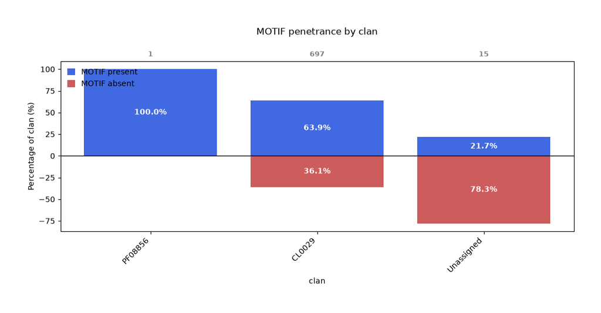

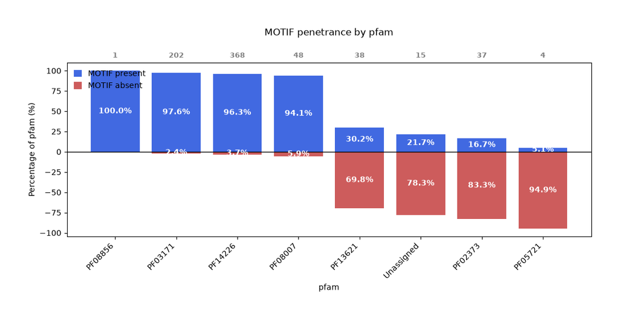

Pattern [(1523, ['H']), (1525, ['D', 'H']), (1652, ['H'])]

```
[dom_5_FOLD] Pattern 2: 791 matches
Pattern definition: [(1523, ['H']), (1525, ['D', 'H']), (1652, ['H'])]
```

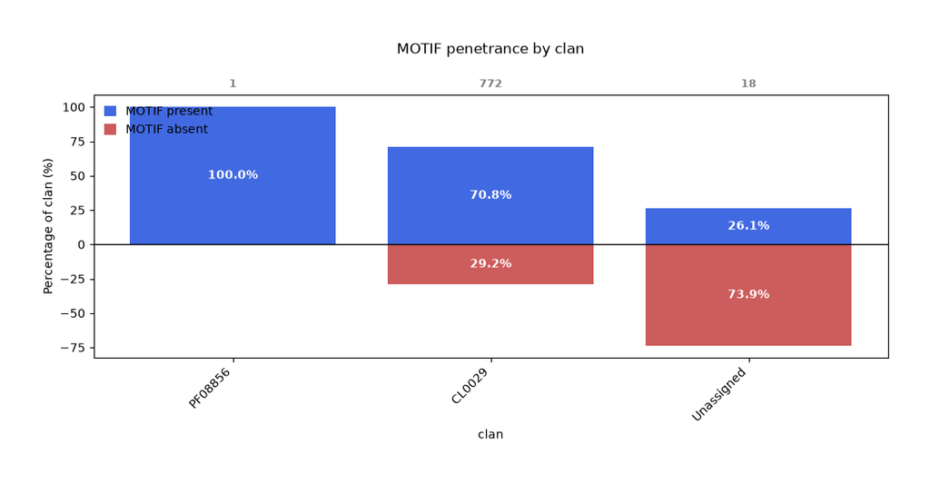

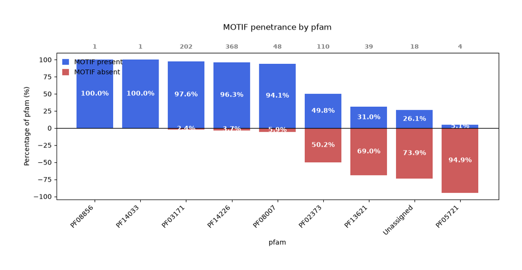

Pattern [(1523, ['H']), (1652, ['H'])]

```
[dom_5_FOLD] Pattern 3: 1104 matches
Pattern definition: [(1523, ['H']), (1652, ['H'])]
```

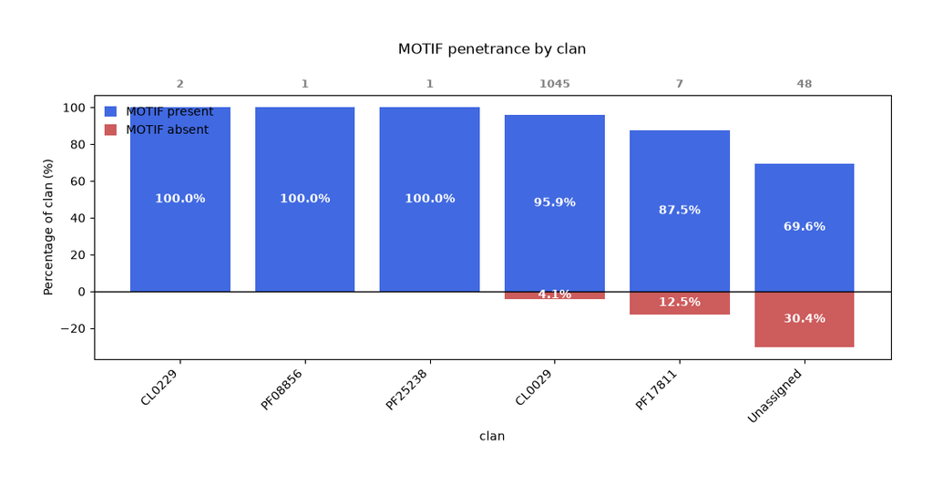

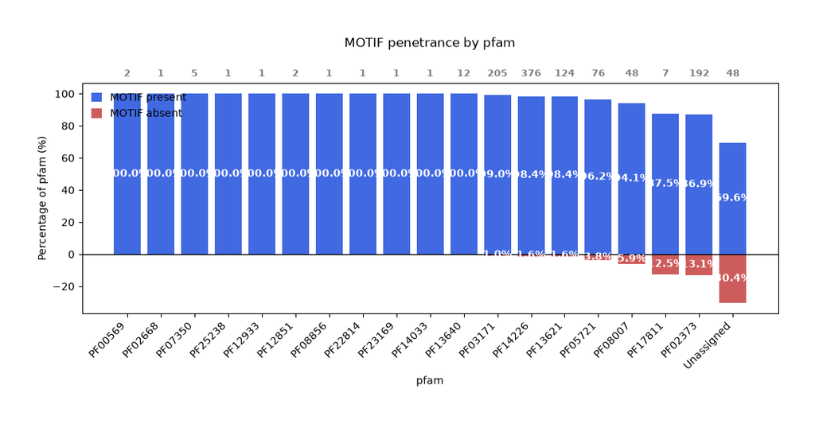

```python
import daliscope.optics.histograms

# define search population. We use a domain population for accurate Pfam annotations.
view_name = 'dom_5_FOLD'
parent_df = project.views[view_name]

daliscope.optics.histograms.set_motif(parent_df, [1523, 1525, 1652], k=4, verbose=True)

# Define all 3 patterns in the list
patterns = [
    [(1523, ["H"]), (1525, ["D"]), (1652, ["H"])],
    [(1523, ["H"]), (1525, ["D", "H"]), (1652, ["H"])],
    [(1523, ["H"]), (1652, ["H"])],
]

view = project.views[view_name]

# Loop over each pattern one by one
for i, pattern in enumerate(patterns, start=1):
    show_heading(f"Pattern {pattern}")
    # Pass a single pattern wrapped in a list: [pattern]
    hits = daliscope.optics.histograms.find_pattern_targets(view, [pattern])

    print(f"\n[{view_name}] Pattern {i}: {len(hits)} matches")
    print(f"Pattern definition: {pattern}\n")

    for category in ['clan', 'pfam']:
        # plot penetrance per category for this pattern
        daliscope.optics.histograms.draw_diverging_percentage_plot(
            view,
            hits=hits,
            grouping_col=category,
            yscale='linear',
        )
```

> In the supplied analysis, HxD...H occurs among CUPIN-annotated and unassigned hits. Inspect the printed counts and family/clan penetrance plots for the current run.

> The second position varies in the motif enumeration. Relaxing that position increases the number of matches; assess recall against the current domain selection and annotations rather than reusing counts from an earlier run.

```python
# 1. Get hits for the specified pattern
hits = daliscope.optics.histograms.find_pattern_targets(view, [patterns[1]])

# 2. Filter for hits where pfam is 'Unassigned'
df = project.views[view_name]
unassigned_hits_df = df[
    (df['target_id'].isin(hits)) &
    (df['pfam'] == 'Unassigned')
]

# 3. Verify sequence context
tmp = list(unassigned_hits_df['sequ_pileup'])
for row in tmp:
    print(row[1500:1540],' ... ',row[1620:1660])

# 4. Print target_id and description
print(f"\nFound {len(unassigned_hits_df)} hits with 'Unassigned' Pfam:\n")
with pd.option_context('display.max_colwidth', None):
    display(unassigned_hits_df[['target_id', 'z_score', 'description']]) #.to_string(index=False))
```

```
PIFWVRPGEREIC..FKDRTPSHADCTGAVG.ILKAIRS.  ...  KLNQI.RRSNIEYVHISLKENCVYFLPRKVIHQFRTISAC
PILWSRHGERQIT..IHDRTNCHAHTTAAVG.LLKA....  ...  ELNQL.HSEGFRYVRLPLRDNDIYFIPRNVVHQFKSVSAV
EWVLLSQ.........GHNTSPHSHGLGTWITVQ......  ...  PHGF....RGGHWCYMVLEPGQTVFFNSGTVHFVFRREAT
EWALLSE.........GHNTAPHSHGFATWITVQ......  ...  Y.......TGGRWRYVILKPGQSVFFGPGTIHFVFRGCQT
SFVLLAS.........GSYSNVHVDINGTWVSCL......  ...  KP......EPGRVKHIVLLAGEMLIMGSLTIHAPLTLEDC
GRLIHYHS.....IHSNLWQQWHYDGIFTVLTTPLFILP.  ...  ........NKKRAIMVNAPPESFIIQVRSALHCV.ENLSR
LAPTGS.....FGNLDQIFAGFHYDNLLTIHGK.......  ...  .........DGTRVPVKVPNGCLLLQILAGFHE..KSLWR
LAPTGLNCY...NEEGTIFAGYHYDNFLTIHGR.......  ...  .........NGEKVAVKVPVGCLLIQCIAGMHE...SLWR
GRLLY.......GNSLSSWCGWHTDGSLTGLTCGMFT...  ...  .......TRNNQIIKVVYGKDDIAYQICATPHCVQSGIER
GRLLY.......GNSLSSWCGWHTDGSLTGLTCSMFT...  ...  .......TRNNQIVKVVYGKDDIAYQICATPHCVQSGIER
GRLLYYYPRQ.....VSSWCGWHTDGSLTGLTCALFTK..  ...  .......TRDDKVVKVTFEENELAYQVCATPHCVKSNVDR
GRLLYYF........ISSWCGWHTDGSLTGLTRAIFS...  ...  .......TRSGQIVKVVYGEDEIAYQICATPHCVRRGLER
LAPTGS.....HGSEGTVFAGFHYDNFLTIHGR.......  ...  ........RNGKKMEVK..VGCLLIQCLAGMHEVV.SLWR
GRLLYYFPR......VSSWCGWHTDGSLTGLTCGLFTK..  ...  .......TRDNQVVKVVFDEDQLAYQICATPHCVQSNVDR
ARLLHYFP.........SWCTTHLDGCLTGLTSAMFVDE.  ...  .......SRAGQVHKVSIPRDALAFQTKAVPHFVKMSIAR
ARLLHY.YPQTA......WCATHLDGCLTGLTSAMFVDE.  ...  .......SRTGDIVQVKIPRDCIAFQTKAVPHFVRSRIAR
AHINV............SVGRWHTDYPWVCVCMLSDP...  ...  .......KGDGTIAKIGPQVGWAVMQGGCIEHIAL.TGER
ARLLH............DWCATHLDGCLTGL...MFIDE.  ...  .......SRTGQTVQVKIPRDCIAFQTKAVPHFV..RIAR

Found 18 hits with 'Unassigned' Pfam:
```

|  | target_id | z_score | description |
| --- | --- | --- | --- |
| 73 | i5geA | 21.0 | STRER/AFDB:AF-A0A0K0DS03-F1 Uncharacterized protein UNCHARACTERIZED PROTEIN; |
| 74 | kc2hA | 20.9 | SCHMA/AFDB:AF-A0A3Q0KEA1-F1 Uncharacterized protein UNCHARACTERIZED PROTEIN; |
| 349 | vx5rA | 14.8 | SPOS1/AFDB:AF-U7PWI3-F1 JmjC domain-containing protein JMJC DOMAIN-CONTAINING PROTEIN; |
| 359 | wboqA | 14.4 | 9PEZI1/AFDB:AF-A0A175W0J7-F1 JmjC domain-containing protein JMJC DOMAIN-CONTAINING PROTEIN; |
| 363 | w46xA | 14.1 | 9EURO1/AFDB:AF-A0A1C1CJD8-F1 Uncharacterized protein UNCHARACTERIZED PROTEIN; |
| 1058 | haigA | 7.8 | SOYBN:AF-I1JF77-F1 UNCHARACTERIZED PROTEIN; |
| 1075 | fxwlA | 7.7 | DICDI:AF-Q55GT3-F1 FE2OG DIOXYGENASE DOMAIN-CONTAINING PROTEIN; |
| 1081 | ajz7A | 7.7 | ARATH:AF-Q9FI36-F1 2-OXOGLUTARATE (2OG) AND FE(II)-DEPENDENT OXYGENA |
| 1091 | hsgkA | 7.6 | SOYBN:AF-K7LFI0-F1 FE2OG DIOXYGENASE DOMAIN-CONTAINING PROTEIN; |
| 1092 | hl87A | 7.6 | SOYBN:AF-I1LNX0-F1 FE2OG DIOXYGENASE DOMAIN-CONTAINING PROTEIN; |
| 1095 | cl6qA | 7.6 | ORYSJ:AF-Q6I615-F1 OS05G0556000 PROTEIN; |
| 1096 | ajuvA | 7.6 | ARATH:AF-F4JT13-F1 2-OXOGLUTARATE (2OG) AND FE(II)-DEPENDENT OXYGENA |
| 1104 | bhvqA | 7.6 | MAIZE:AF-B6TNK2-F1 2-OXOGLUTARATE (2OG) AND FE(II)-DEPENDENT OXYGENA |
| 1116 | bde5A | 7.4 | MAIZE:AF-A0A1D6MC07-F1 2-OXOGLUTARATE (2OG) AND FE(II)-DEPENDENT OXYGENA |
| 1123 | j7xvA | 7.3 | 9EURO2/AFDB:AF-A0A0D2EKU5-F1 Unplaced genomic scaffold supercont1.8, whole genome shotgun sequence UNPLACED GENOMIC SCAFFOLD SUPERCONT1.8, WHOLE GEN |
| 1126 | w27sA | 7.2 | SPOS1/AFDB:AF-U7Q287-F1 Uncharacterized protein UNCHARACTERIZED PROTEIN; |
| 1140 | w855A | 7.0 | 9EURO1/AFDB:AF-A0A1C1CZ39-F1 Uncharacterized protein UNCHARACTERIZED PROTEIN; |
| 1147 | whg7A | 6.7 | 9PEZI1/AFDB:AF-A0A175VWB9-F1 Uncharacterized protein UNCHARACTERIZED PROTEIN; |

Here, `Unassigned` means that no Pfam family was assigned to the matched region. It does not mean the entire protein is functionally uncharacterized: some descriptions refer to dioxygenase or JmjC proteins. Inspect the listed target descriptions and sequence context before interpreting these hits.